# Assignment 2

## Name: Mohammad Mahmoud Hafez Abd-Alazeem Al-Berry

## Sec 3

```python
import cv2
import numpy as np
import math
from matplotlib import pyplot as plt
from skimage.feature import hog
```

## Problem 1

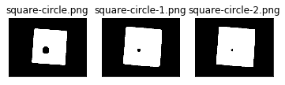

```python
img = cv2.imread('image2_folder/square-circle.png' , 0)
path = 'image2_folder/'
circle = cv2.getStructuringElement(cv2.MORPH_ELLIPSE,(17,17))
square = cv2.getStructuringElement(cv2.MORPH_RECT,(17,17))
res1 = cv2.dilate(img , circle , iterations = 1)
res2 = cv2.dilate(img , square , iterations = 1)
imgs = [img , res1 , res2]
titles = ['square-circle.png','square-circle-1.png','square-circle-2.png']
result_folder = 'res/'
for i in range(3):
    cv2.imwrite(result_folder+titles[i],imgs[i])
    plt.subplot(1,3,i+1),plt.imshow(imgs[i] ,'gist_gray')
    plt.title(titles[i])
    plt.xticks([]),plt.yticks([])
plt.show()
```

#### Here I used cv2.getstructureingElement(cv2.MORPH_ELLIPSE , (17,17))

#### to construct circuler kernel of ones and diameter of 17 pixel

#### and cv2.getConstrucreingElementCcv2.MORPH_RECT , (17,17)) to get just ordinary array of ones shape[17,17]

#### we could get it using np.ones((17,17) , dtype=np.uint8) // same result

### from the result I found that as I Guessed the Circlar kernel have more smooth edges as curves and keeps the circular shapes unlike the square kernel it distort the black circule

## Problem 2

[figure not shown]

[figure not shown]

```python
img = cv2.imread(path+'cameraman.png',0)
plt.imshow(img ,'gist_gray')
plt.title('original img')
plt.show()
kernel1 = cv2.getStructuringElement(cv2.MORPH_RECT,(3,3))
result = cv2.erode(img , kernel1 , iterations = 1)
kernel2 = cv2.getStructuringElement(cv2.MORPH_ELLIPSE,(5,5))
result = cv2.dilate(result , kernel2 , iterations = 1)
#result = cv2.dilate(result , kernel2 , iterations = 1)


cv2.imwrite(result_folder+'cameraman-denoised.png',result)
plt.imshow(result ,'gist_gray')
plt.title('cameraman-denoised.png')
plt.show()
```

# this image has salt and pepper noise not just pepper so i can't denoise the white dots with dilation only so i did erosion first to get rid of white dots then I did dilation to get rid of black dots

## Problem 3

[figure not shown]

[figure not shown]

```python
def sub(m , x):
    m = m-x
    m=np.where(m < 0, 0, m)
    return m

img = cv2.imread(path+'lady.png',0)
plt.imshow(img ,'gist_gray')
plt.title('original img')
plt.show()

kernel = cv2.getStructuringElement(cv2.MORPH_RECT,(3,3))
result = cv2.dilate(img , kernel , iterations = 1)
result = sub(result , img)

cv2.imwrite(result_folder+'lady-edge.png',result)
plt.imshow(result ,'gist_gray')
plt.title('lady-edge.png')
plt.show()
```

## Problem 4

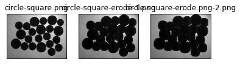

```python
img = cv2.imread(path+'Circle.png',0)

circle = cv2.getStructuringElement(cv2.MORPH_ELLIPSE,(15,15))
square = cv2.getStructuringElement(cv2.MORPH_RECT,(15,15))
res1 = cv2.erode(img , circle , iterations = 1)
res2 = cv2.erode(img , square , iterations = 1)
imgs = [img , res1 , res2]
titles = ['circle-square.png','circle-square-erode-1.png','circle-square-erode.png-2.png']
result_folder = 'res/'
for i in range(3):
    cv2.imwrite(result_folder+titles[i],imgs[i])
    plt.subplot(1,3,i+1),plt.imshow(imgs[i] ,'gist_gray')
    plt.title(titles[i])
    plt.xticks([]),plt.yticks([])
plt.show()
```

### here i used 2 kernel structures circle and square , the cicular kernel keeps the curves and as large as the kernel goes the hols or the black circles goes bigger without any distortion ,but in the squre kernel the bigger the kernel goes the more black circles tends to be squares

# Problem 6

[figure not shown]

[figure not shown]

```python
img = cv2.imread(path+'cameraman.png',0)
plt.imshow(img ,'gist_gray')
plt.title('original img')
plt.show()
kernel1 = cv2.getStructuringElement(cv2.MORPH_ELLIPSE,(5,5))
result = cv2.erode(img , kernel1 , iterations = 1)
kernel2 = cv2.getStructuringElement(cv2.MORPH_ELLIPSE,(7,7))
result = cv2.dilate(result , kernel2 , iterations = 1)
#result = cv2.dilate(result , kernel2 , iterations = 1)


cv2.imwrite(result_folder+'cameraman-erode.png',result)
plt.imshow(result ,'gist_gray')
plt.title('cameraman-erode.png')
plt.show()
```

# same as problem 2 >> erode for denoising salt and dilate for denoising pepper

# Problem 7

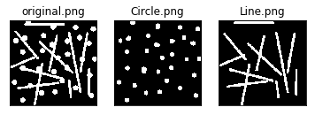

```python
img = cv2.imread(path+'Circle_and_Lines.png',0)


circle = cv2.getStructuringElement(cv2.MORPH_ELLIPSE,(11,11))
cir2 = cv2.getStructuringElement(cv2.MORPH_ELLIPSE,(3,3))
square0 = cv2.getStructuringElement(cv2.MORPH_RECT,(41,5))
square1 = cv2.getStructuringElement(cv2.MORPH_RECT,(4,21))
square2 = cv2.getStructuringElement(cv2.MORPH_RECT,(4,4))

def add(m ,x):
    m = m+x
    m=np.where(m > 255, 255, m)
    return m


square = np.zeros((41,41) , dtype=np.uint8)
square[18:23 ,:] = square0
res1 = cv2.morphologyEx(img, cv2.MORPH_OPEN, circle)
res1=cv2.erode(res1 , cir2 , iterations = 1)
res2 = img - img
for i in range(175):
    m = cv2.getRotationMatrix2D((18,18),i,1)
    square3 = cv2.warpAffine(square, m , (36,36))
    res2 = add(res2 , cv2.morphologyEx(img, cv2.MORPH_OPEN, square3))

imgs = [img , res1 , res2]
titles = ['original.png','Circle.png','Line.png' ]
result_folder = 'res/'
for i in range(3):
    cv2.imwrite(result_folder+titles[i],imgs[i])
    plt.subplot(1,3,i+1),plt.imshow(imgs[i] ,'gist_gray')
    plt.title(titles[i])
    plt.xticks([]),plt.yticks([])
plt.show()
#################################################
```

to do circle counter I did Erosion with the diameter of the circle to get array of points instead of circles and with 2 neasted for searching for white dots I could determin where is the circule and count them . dots[x-5:x+15 , y-5:y+15] = 0 and this line to get rid of white dots we couted and it's neabors points

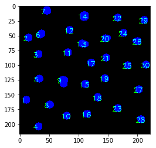

```python
# Counting Circles
circles_img = cv2.imread(result_folder + 'Circles.png' , 0)
count = 0
kernel = np.zeros((15,15) , dtype = np.uint8)
kernel[7][7] = 255
dots = cv2.erode(circles_img , np.ones((10,10),dtype=np.uint8))
lables = np.zeros(dots.shape , dtype=np.uint8)
for y in range(dots.shape[1]):
    for x in range(dots.shape[0]):
        if (dots[x][y] == 255):
            count +=1
            cv2.putText(lables, "{}".format(str(count)), (int(y) - 10, int(x)+5),cv2.FONT_HERSHEY_SIMPLEX, 0.4, (255), 1)
            dots[x-5:x+15 , y-5:y+15] = 0
labled_cir = np.zeros((dots.shape[0],dots.shape[1],3),dtype=np.uint8)
labled_cir[:,:,2] = circles_img
labled_cir[:,:,1] = lables
circles_img += lables
plt.imshow(labled_cir)
plt.show()
```

[output not shown]

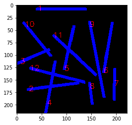

```python
lines_img = cv2.imread(result_folder + 'Line.png' , 0)
count = 0
# making an img that have white line in it's center
square0 = cv2.getStructuringElement(cv2.MORPH_RECT,(40,5))
square = np.zeros((90,90) , dtype=np.uint8)
square[42:47 ,25:65] = square0
lines = []
lables = np.zeros(dots.shape , dtype=np.uint8)
img = lines_img
tmp = img
ret , p_tmp = cv2.threshold(tmp, 256, 256, cv2.THRESH_BINARY)
#rotating that line 177 Degree is enough to detect every line in the img
for i in range(177):
    m = cv2.getRotationMatrix2D((45,45),i,1)
    square3 = cv2.warpAffine(square, m , (90,90))
    tmp = cv2.morphologyEx(img, cv2.MORPH_OPEN, square3)
    if(np.sum(tmp) == 0): continue
    ret , tmp = cv2.threshold(tmp, 150, 255, cv2.THRESH_BINARY)
    loop_back = cv2.bitwise_and(tmp , tmp , mask = p_tmp)
    p_tmp = tmp
    if(np.sum(loop_back)  > 10):
        lines[-1] =(cv2.bitwise_or(tmp,lines[-1]))
        continue
    lines.append(tmp)
# for every img we got from previos step we could get more than one line so check contours
for l in lines:
    #l = cv2.Canny(l,100,255)
    im2, contours, hierarchy = cv2.findContours(l,1 , cv2.CHAIN_APPROX_SIMPLE)
    for i in range(len(contours)):
            c = contours[i]
            c= cv2.convexHull(c)
            count +=1
            x = c[c.shape[0]//2][0][0]
            y = c[c.shape[0]//2][0][1]
            #cv2.drawContours(cont, [c], 0, (0,0,255), 1)
            cv2.putText(lables, "{}".format(str(count)), (int(x), int(y)+4),cv2.FONT_HERSHEY_SIMPLEX, 0.5, (255), 1)
print(count)

labled_lines = np.zeros((dots.shape[0],dots.shape[1],3),dtype=np.uint8)
labled_lines[:,:,2] = lines_img
labled_lines[:,:,0] = lables

plt.imshow(labled_lines)
plt.show()
```

# Problem 8

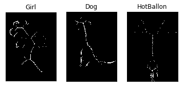

```
Center Of Mass for:Girl:  (142, 175)      And its Area:  34133.0
Center Of Mass for:Dog:  (119, 178)      And its Area:  25647.5
Center Of Mass for:HotBallon:  (139, 148)      And its Area:  63515.0
```

```python
circle = cv2.getStructuringElement(cv2.MORPH_ELLIPSE,(8,8))

path = 'image2_folder/'
girl = cv2.imread(path +'girl.png' , 0)
ret , girl = cv2.threshold(girl, 127, 255, cv2.THRESH_BINARY)
girl = cv2.bitwise_not(girl)

HotBallon = cv2.imread(path +'HotBallon.png' , 0)
ret , HotBallon = cv2.threshold(HotBallon, 127, 255, cv2.THRESH_BINARY)
HotBallon = cv2.bitwise_not(HotBallon)

dog = cv2.imread(path +'Dog.png' , 0)
ret , dog = cv2.threshold(dog, 127, 255, cv2.THRESH_BINARY)
dog = cv2.bitwise_not(dog)

falcon = cv2.imread(path +'falcon.png' , 0)
ret ,falcon = cv2.threshold(falcon, 127, 255, cv2.THRESH_BINARY)
falcon = cv2.bitwise_not(falcon)


def skel(img):
    sk = np.zeros((img.shape[0],img.shape[1]),dtype=np.uint8)
    k = cv2.getStructuringElement(cv2.MORPH_ELLIPSE,(7,7))
    done = False
    while(not done):
        eroded = cv2.erode(img , k)
        tmp = cv2.dilate(eroded , k)
        tmp = sub(img , tmp)
        sk = cv2.bitwise_or(sk ,tmp)
        img = cv2.erode(img , k)

        #min_val, max_val, min_loc, max_loc = cv2.minMaxLoc(img)
        done =(cv2.countNonZero(img) == 0)
    #sk = cv2.dilate(sk , np.ones((3,3)))
    return sk

imgs = [skel(girl) , skel(dog) , skel(HotBallon)]
titles = ['Girl','Dog','HotBallon']
result_folder = 'res/'
for i in range(3):
    #cv2.imwrite(result_folder+titles[i],imgs[i])
    plt.subplot(1,3,i+1),plt.imshow(imgs[i] ,'gist_gray')
    plt.title(titles[i])
    plt.xticks([]),plt.yticks([])
plt.show()

# for finding out center of mass
def centerOfMass(img):
    im2,contours,hierarchy = cv2.findContours(img, 1, 2)
    cx = 0
    cy = 0
    area = 0
    for c in contours:
        m = cv2.moments(c)
        a = cv2.contourArea(c)
        cx = int((area * cx + (a*m['m10']/(m['m00']+0.00000001)))//(a + area+0.00000001))
        cy = int((area * cy + (a*m['m01']/(m['m00']+0.00000001)))//(a+area+0.00000001))
        area += a
    point = (cx,cy)

    return point , area

imgs = [girl , dog , HotBallon]
for i in range(3):
    point , Area = centerOfMass(imgs[i])
    print('Center Of Mass for:'+titles[i]+': ',point , '     And its Area: ', Area)
```

# Problem 9

```
--------------------------------------------------
Isolated points
```

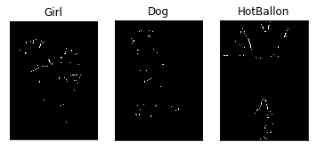

```
--------------------------------------------------
junction points
```

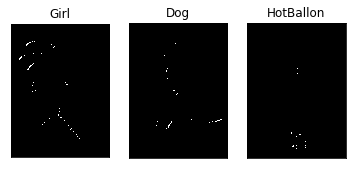

```python
# getting the 3 images
sk_dog = skel(dog)
sk_girl = skel(girl)
sk_ballon = skel(HotBallon)

# contruct the kernels
k_isolated = np.array([
                      [-1,-1,-1],
                      [-1,1,-1],
                      [-1,-1,-1]],dtype="int")

k_junction = np.array([
                      [-1,1,0],
                      [1,1,1],
                      [0,1,0]],dtype="int")

# Build our function that return HIT MISS
def HIT_MISS(img , k):
    out = cv2.morphologyEx(img , cv2.MORPH_HITMISS , k)
    out = cv2.dilate(out , np.ones((3,3),dtype=np.uint8))
    return out

# making arrays of imgs and titles
imgs = [sk_girl , sk_dog , sk_ballon]
titles = ['Girl','Dog','HotBallon']
result_folder = 'res/'
## action time :D
print('-'*50)
print('Isolated points')
for i in range(3):
    plt.subplot(1,3,i+1),plt.imshow(HIT_MISS(imgs[i],k_isolated) ,'gist_gray')
    plt.title(titles[i])
    plt.xticks([]),plt.yticks([])
plt.show()
print('-'*50)
print('junction points')
for i in range(3):
    plt.subplot(1,3,i+1),plt.imshow(HIT_MISS(imgs[i],k_junction) ,'gist_gray')
    plt.title(titles[i])
    plt.xticks([]),plt.yticks([])
plt.show()
```

# problem 10

```
chars count is:  223
```

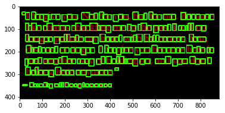

```python
words = cv2.imread(path + 'words.png' , 0)
words = cv2.resize(words, (0,0), fx=2, fy=2)
#words = cv2.bitwise_not(words)
words = cv2.GaussianBlur(words,(5,5),0)
#######################3
# to frequency domain
f = np.fft.fft2(words)
f_shift = np.fft.fftshift(f)
mag = 20 * np.log(np.abs(f_shift))
#########################
#butterworth filter
def dist( x1 , y1 , x2 , y2):
    return (math.sqrt((x1-x2)**2+(y1-y2)**2))
def butterworth_lpf(img ,d, order):
    rows , cols = img.shape
    cx , cy = rows//2 , cols//2
    filt = np.zeros((rows,cols) , dtype=np.float32)
    for x in range(rows):
        for y in range(cols):
            filt[x][y]=dist(x,y,cx,cy)
    #
    H =1/(1+(filt/d)**order)
    filtered = H * img

    return filtered
##############
# doing filtering
#circle = cv2.getStructuringElement(cv2.MORPH_ELLIPSE,(200,200))

f_shift = butterworth_lpf(f_shift,1500,15)

mag = 20 * np.log(np.abs(f_shift))
#print(mag[0])
######################3
# construct the img again
f_ishift = np.fft.ifftshift(f_shift)
img_back = np.fft.ifft2(f_ishift)
img_back = np.abs(img_back)
img_back = img_back.astype(np.uint8)
#words = cv2.bitwise_not(words)
#words = cv2.GaussianBlur(words , (3,3),0)
#words = cv2.addWeighted(words,0.5,-10.5,10,100)
#words = cv2.dilate(words , circle)
thresh = cv2.adaptiveThreshold(img_back ,255 , cv2.ADAPTIVE_THRESH_GAUSSIAN_C ,cv2.THRESH_BINARY_INV ,11,2 )
#ret , thresh = cv2.threshold(img_back , 170 , 255 ,cv2.THRESH_BINARY_INV )
#thresh = cv2.erode(thresh , np.ones((2,2),dtype=np.uint8))
#thresh = cv2.dilate(thresh , np.ones((3,3),dtype=np.uint8))

im2,contours,hierarchy = cv2.findContours(thresh, cv2.RETR_TREE, cv2.CHAIN_APPROX_SIMPLE)
rects = []
# make rectangles over chars
for i in range(len(contours)):
    ctr = contours[i]
    # remove inner contours and small ones
    if hierarchy[0][i][3]==-1 and cv2.contourArea(ctr) > 60:
        rects.append(cv2.boundingRect(ctr))
im = np.zeros((words.shape[0],words.shape[1],3) , dtype=np.uint8)
for rect in rects:
    # Draw the rectangles
    cv2.rectangle(im, (rect[0], rect[1]), (rect[0] + rect[2], rect[1] + rect[3]), (0, 255, 0), 3)
    # Make the rectangular region around the Chars

print('chars count is: ',len(rects))
#cv2.drawContours(c , rects , -1 ,(255))
im[:,:,0] = cv2.bitwise_not(words)
plt.imshow(im)
plt.show()
```